# 대한민국 제21대 국회의원 선거

제20대 총선 (2016)

[Tidyverse Korea](https://www.facebook.com/groups/tidyverse/)

2020-03-24

# 1 총선 선거구 [^1]

제20대 선거구 데이터는 팀포퐁 [GitHub](https://github.com/southkorea/southkorea-maps)에서 가져온다. GeoJSON과 Topo JSON 형식을 모두 지원한다. 과거 `ogrListLayers` 함수를 통해서 사용할 `layer=`를 확인해서 데이터를 읽어왔다. 하지만, 이제는 `sf` 팩키지를 통해서 통일된 방식으로 가져올 수 있게 되었다.

[2020년 21대 국회의원 총선거 지도](https://github.com/OhmyNews/2020_21_elec_map)는 VW Lab 김승범 소장님 [대한민국 행정동 경계 파일](https://github.com/vuski/admdongkor)을 기반으로 하여 오마이뉴스에서 제작한 지도입니다.

## 1.1 데이터 가져오기 [^2]

정성스럽게 가져온 선거구 데이터는 작업하기에 너무 상세하여, 다른 말로 하면 상세하게 표현하는데 너무 시간이 많이 걸린다. 사실 선거관련 데이터는 자세한 사실적인 표현보다 시각적으로 직관적 표현에 집중하기 때문에 `.geojson` 파일을 가져와서 크기를 줄이는 작업이 필요하다. 이를 위해서 `rmapshaper` 팩키지 `ms_simplify()` 함수를 사용하게 되면 크게 속도를 향상시킬 수 있다.

```r
library(tidyverse)
library(sf)
library(rmapshaper)

precinct_19 <- st_read("data/shapefile/election_district_20/assembly-precinct-19-geo.json") %>%    ms_simplify(keep=0.01)
# precinct_20 <- st_read("data/shapefile/election_district_20/assembly-precinct-20-geo.json")
precinct_20 <- st_read("data/shapefile/election_district_20/election_district_20.shp") %>%
   ms_simplify(keep=0.01)
precinct_21 <- st_read("data/shapefile/2020_21_elec_map/2020_21_elec_253.json") %>%
  ms_simplify(keep=0.01)
```

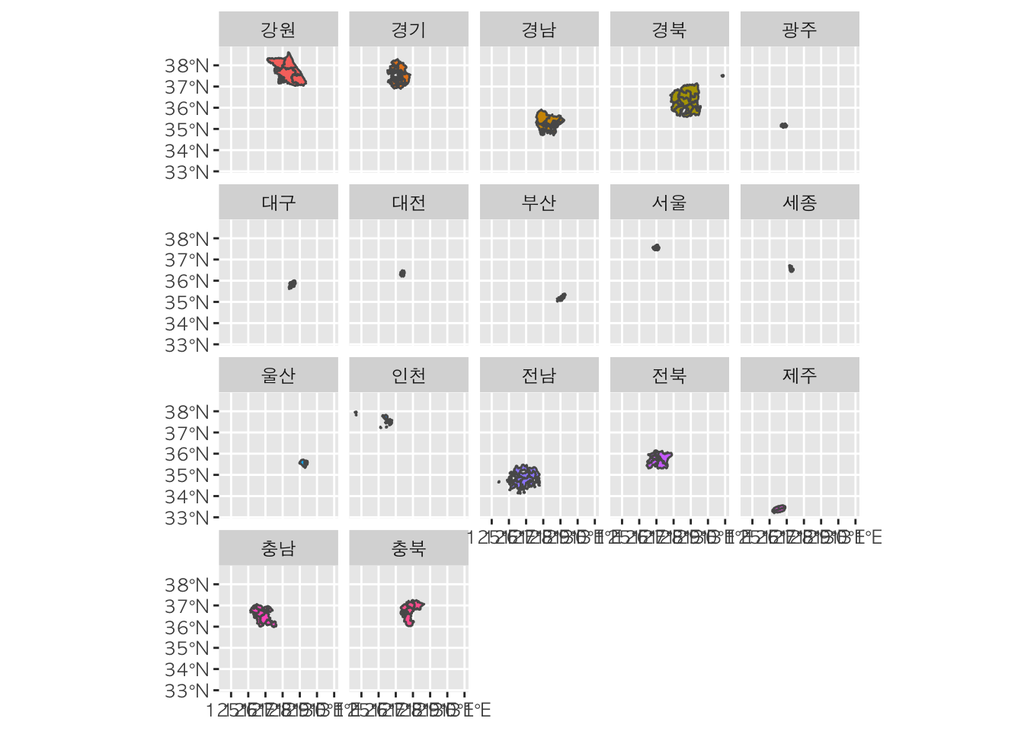

```r
precinct_21 %>%
  ggplot() +
    geom_sf(aes(fill=SGG_1)) +
    facet_wrap(~SGG_1) +
    theme(legend.position = "none")
```

[^1]: [Overcoming D3 Cartographic Envy With R + ggplot](https://rud.is/b/2014/09/26/overcoming-d3-cartographic-envy-with-r-ggplot/)
[^2]: [Edzer Pebesma, Roger Bivand (2020-02-09), “Spatial Data Science”](https://keen-swartz-3146c4.netlify.com/index.html)